# Reproducible Research: Peer Assessment 1

## Loading and preprocessing the data

```r
if(!file.exists('activity.csv')){
  unzip('activity.zip')
}

steps_data<-read.csv('activity.csv')
```

## What is mean total number of steps taken per day?

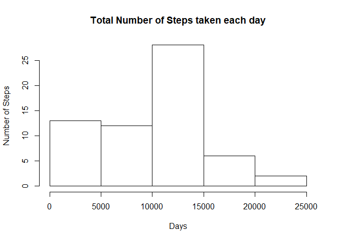

```r
##Convert dates to date class
steps_data$date<-as.Date(steps_data$date,"%Y-%m-%d")

##Sum by date
steps_per_day<-aggregate(steps_data$steps,by=list(date=steps_data$date),FUN=sum,na.rm=TRUE)

##Draw a histogram
hist(steps_per_day$x,main="Total Number of Steps taken each day",xlab="Days",ylab="Number of Steps")
```

```r
##Calculate Mean
steps_per_day_mean<-mean(steps_per_day$x)

##Calculate Median
steps_per_day_median<-median(steps_per_day$x)
```

Mean number of steps per day: `9354.2295082`

Median number of steps per day: `10395`

## What is the average daily activity pattern?

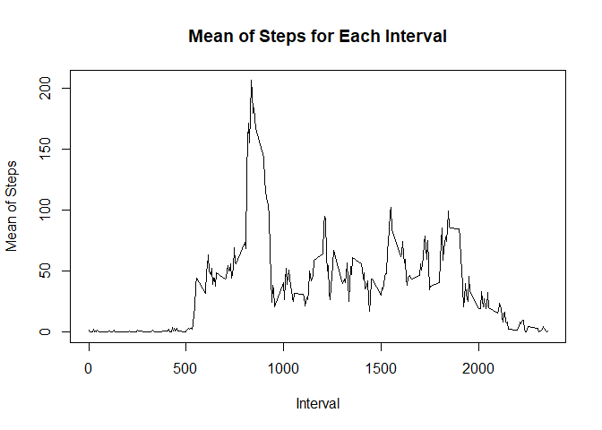

```r
##Calculate mean for each interval
steps_per_interval_mean<-aggregate(steps_data,by=list(interval=steps_data$interval),FUN=mean,na.rm=TRUE)

#Time series plot
plot(steps_per_interval_mean$interval,steps_per_interval_mean$steps,type="l",main = "Mean of Steps for Each Interval",xlab = "Interval",ylab = "Mean of Steps")
```

```r
##Find the interval with the maximum number of steps
max_interval<-(steps_per_interval_mean[which.max(steps_per_interval_mean$steps),])$interval
```

Interval `835`,on average across all the days in the data set, contains the maximum number of steps

## Imputing missing values

```r
##Total number of missing values
num_missing<-sum(is.na(steps_data$steps))
```

Number of missing values: `2304`

The strategy I would use to fill missing values is via mean steps for intervals.

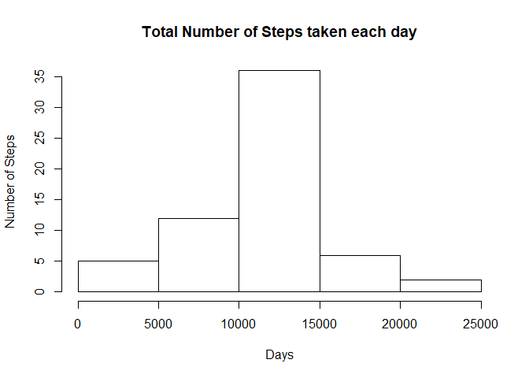

```r
##Use mean steps for the interval to fill missing values

#Make a copy of the steps data
steps_data_imputed<-steps_data

##Find steps with value as NA and replace with the mean value for the interval calculated above.
for(i in 1:length(steps_data_imputed$steps)){
  if(is.na(steps_data_imputed$steps[i])){
    steps_data_imputed$steps[i]<-steps_per_interval_mean$steps[which(steps_per_interval_mean$interval==steps_data_imputed$interval[i])]
  }
}

##Sum by date
steps_imputed_per_day<-aggregate(steps_data_imputed$steps,by=list(date=steps_data$date),FUN=sum,na.rm=TRUE)

##Draw a histogram
hist(as.numeric(steps_imputed_per_day$x),main="Total Number of Steps taken each day",xlab="Days",ylab="Number of Steps")
```

```r
##Calculate Mean
steps_imputed_per_day_mean<-mean(steps_imputed_per_day$x)

##Calculate Median
steps_imputed_per_day_median<-median(steps_imputed_per_day$x)
```

## Are there differences in activity patterns between weekdays and weekends?

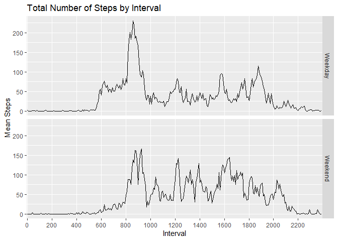

```r
library(ggplot2)
#Assign a Weekday or Weekend tag to each row based on the date.
for(j in 1:length(steps_data_imputed$steps)){
  if(weekdays(steps_data_imputed$date[j])=="Saturday" || weekdays(steps_data_imputed$date[j])=="Sunday"){
    steps_data_imputed$wkdorwknd[j]="Weekend"
  }else{
    steps_data_imputed$wkdorwknd[j]="Weekday"
  }
}

steps_data_imputed$wkdorwknd<-as.factor(steps_data_imputed$wkdorwknd)

#Take the mean of the steps for each interval categorized by weekday/weekend.
steps_imputed_per_interval_wkdorwknd<-aggregate(steps_data_imputed$steps,by=list(wkdorwknd=steps_data_imputed$wkdorwknd,interval=steps_data_imputed$interval),FUN=mean,na.rm=TRUE)

#Provide data to ggplot including the values for x,y axis
wkd_wknd_plot<-ggplot(steps_imputed_per_interval_wkdorwknd,aes(x=factor(interval),y=x,group=1))

#Specify the plot type - line graph
wkd_wknd_plot<-wkd_wknd_plot+geom_line()

#Create a column of 2 plots - one for each weekday and weekend
wkd_wknd_plot<-wkd_wknd_plot+facet_grid(wkdorwknd~.)

#Space out the x-axis scale
wkd_wknd_plot<-wkd_wknd_plot+scale_x_discrete(breaks=seq(0,2400,by=200))

#Add x and y axis labels
wkd_wknd_plot<-wkd_wknd_plot+xlab("Interval")+ylab("Mean Steps")

#Add plot title
wkd_wknd_plot<-wkd_wknd_plot+ggtitle("Total Number of Steps by Interval")

print(wkd_wknd_plot)
```

Based on the two plots above, it seems during the morning hours on a weekday the step activity is higher than during the same hours on a weekend. However, the number of steps taken on the weekend seems to be more than those taken on a weekday possibly due to more recreational activities on a weekend.